# Entendendo o Comportamento do Mercado Cinematográfico com Dados

Saulo Ferreira

23/07/2020

## Introdução

### Propósito

O cinema é um dos mercados de entretenimento que mais faturam no mundo há décadas e resiste forte em um cenário onde a concorrência sempre se mostrou mais acessível e barata, como televisão, mídias físicas e streaming. Além disso, os filmes costumam ser reflexos de uma diversidade de culturas ao redor do mundo, trazendo todos os seus costumes e práticas para outros pontos do planeta. A produção cinematográfica como expressão artística é uma forma fácil tanto de repassar quanto de compreender questões sensíveis na sociedade, como conceitos religiosos, dificuldades de um povo, críticas políticas e movimentos sociais.

Neste ponto, é importante entender de qual maneira isso é realizado e como isso é recebido pelo público. Por exemplo, o gênero mais assistido pelo público, o mais bem avaliado, a arrecadação média de filmes melhor avaliados, o mês onde há mais lançamentos e que tipos de gêneros os filmes de cada língua estrangeira busca explorar.

### Relevância

Acerca desses dados, pode-se avaliar como funciona o mercado cinematográfico global, o que é interessante tanto para produtoras que buscam desenvolver suas produções quanto para cineastas que desejam descobrir qual a melhor maneira de passar a sua mensagem.

Tendo em mãos uma quantidade considerável de dados sobre filmes nas últimas décadas, pode-se realizar um tratamento mais eficaz de acordo com cada tipo de informação que se espera extrair deles, pois é de se esperar que nem sempre a formatação dos dados que recebemos é adequada para a resolução do nosso problema.

### Abordagem da Análise

Para termos uma boa quantidade de dados dentro do contexto do nosso problema, foi selecionado uma base de dados com cerca de 45 mil informações de filmes listados no *Full MovieLens Dataset* até 2017. Neste dataset, há 24 colunas informando título do filme, coleção que o filme pertence, seu custo, gêneros, produtoras envolvidas, língua original, país de origem, ano, arrecadação, número e média de avaliações no TBMDB e IMDB, etc.

Com este dataset em mãos, iremos criar gerar novas tabelas para que possamos separar dados que estão inicialmente amontoados em colunas únicas. Estes dados serão tratados e formatados para melhor entendimento, para que possamos, depois, agrupar dados correlacionados, detectar informações desejadas e gerar gráficos. Com esses gráficos, podemos discutir os resultados e tentar relacioná-los entre si, afinal, o mercado do cinema tem um motor de impulsão próprio, onde filmes aclamados acabam por abrir grande margem para vários outros de sua categoria serem produzidos em larga escala.

Os gráficos, tabelas e relatórios gerados nos darão uma perspectiva mais acertada de como se comporta o mercado cinematográfico ao longo dos anos, como tendências se criam e como são recebidos pela crítica e pelo público diferentes tipos de filmes, de diferentes países com suas pluralidades de gêneros.

## Pacotes Requeridos

| Pacote | Descrição |
| --- | --- |
| `library(rjson)` | Manipulação de dados JSON |
| `library(dplyr)` | Manipulação de tabelas, como filtragem, seleção e agrupamento |
| `library(tidyr)` | Manipulação de tabelas, como separação e junção de colunas |
| `library(ggplot2)` | Geração de gráficos através de dados |
| `library(scales)` | Manipulação de datas para visualização em gráficos |
| `library(tm)` | Mineração, tratamento e análise de texto |
| `library(wordcloud)` | Geração de nuvens de palavras |
| `library(DT)` | Geração de tabelas interativas |
| `library(ggrepel)` | Personalização de legenda dos gráficos |

```r
library(rjson)
library(dplyr)
library(tidyr)
library(ggplot2)
library(scales)
library(tm)
library(wordcloud)
library(kableExtra)
library(DT)
library(ggrepel)
```

## Preparação dos Dados

```r
movies_root <- read.csv("original_data/movies_metadata.csv", stringsAsFactors = F)
```

### O Dataset

O dataset utilizado foi o [The Movies Dataset](https://www.kaggle.com/rounakbanik/the-movies-dataset), uma base de dados baixada do Kaggle com 45,463 filmes, cada um com 24 colunas. O dataset é uma versão da [MovieLens Dataset](https://grouplens.org/datasets/movielens/), com filmes lançados até julho de 2017. Por este motivo, muitas das nossas análises considerarão os filmes até 2016, para se ter uma noção mais completa dos dados do ano.

As colunas do dataset são:

- adult: booleano
- belongs_to_collection: caractere
- budget: numérico
- genres: caractere
- homepage: caractere
- id: numérico
- imdb_id: numérico
- original_language: caractere
- original_title: caractere
- overview: caractere
- popularity: numérico
- poster_path: caractere
- production_companies: caractere
- production_countries: caractere
- release_date: caractere
- revenue: numérico
- runtime: numérico
- spoken_languages: caractere
- status: caractere
- tagline: caractere
- title: caractere
- video: booleano
- vote_average: numérico
- vote_count: numérico

Muitas destas colunas não são utilizadas na análise. Portanto, a descrição das mais importantes estará no final deste tópico.

### Tratamentos realizados

#### **Formato inicial**

Inicialmente, foi notado que algumas colunas estavam com valores em formato JSON, portanto, utilizou-se o pacote *rjson* para tratar esses dados.

```r
sample <- movies_root %>% select(belongs_to_collection, production_companies, genres)
knitr::kable(head(sample), format = "html") %>% kable_styling()
```

| belongs_to_collection | production_companies | genres |
| --- | --- | --- |
| {“id”: 10194, “name”: “Toy Story Collection”, “poster_path”: “/7G9915LfUQ2lVfwMEEhDsn3kT4B.jpg”, “backdrop_path”: “/9FBwqcd9IRruEDUrTdcaafOMKUq.jpg”} | [{“name”: “Pixar Animation Studios”, “id”: 3}] | [{“id”: 16, “name”: “Animation”}, {“id”: 35, “name”: “Comedy”}, {“id”: 10751, “name”: “Family”}] |
|  | [{“name”: “TriStar Pictures”, “id”: 559}, {“name”: “Teitler Film”, “id”: 2550}, {“name”: “Interscope Communications”, “id”: 10201}] | [{“id”: 12, “name”: “Adventure”}, {“id”: 14, “name”: “Fantasy”}, {“id”: 10751, “name”: “Family”}] |
| {“id”: 119050, “name”: “Grumpy Old Men Collection”, “poster_path”: “/nLvUdqgPgm3F85NMCii9gVFUcet.jpg”, “backdrop_path”: “/hypTnLot2z8wpFS7qwsQHW1uV8u.jpg”} | [{“name”: “Warner Bros.”, “id”: 6194}, {“name”: “Lancaster Gate”, “id”: 19464}] | [{“id”: 10749, “name”: “Romance”}, {“id”: 35, “name”: “Comedy”}] |
|  | [{“name”: “Twentieth Century Fox Film Corporation”, “id”: 306}] | [{“id”: 35, “name”: “Comedy”}, {“id”: 18, “name”: “Drama”}, {“id”: 10749, “name”: “Romance”}] |
| {“id”: 96871, “name”: “Father of the Bride Collection”, “poster_path”: “/nts4iOmNnq7GNicycMJ9pSAn204.jpg”, “backdrop_path”: “/7qwE57OVZmMJChBpLEbJEmzUydk.jpg”} | [{“name”: “Sandollar Productions”, “id”: 5842}, {“name”: “Touchstone Pictures”, “id”: 9195}] | [{“id”: 35, “name”: “Comedy”}] |
|  | [{“name”: “Regency Enterprises”, “id”: 508}, {“name”: “Forward Pass”, “id”: 675}, {“name”: “Warner Bros.”, “id”: 6194}] | [{“id”: 28, “name”: “Action”}, {“id”: 80, “name”: “Crime”}, {“id”: 18, “name”: “Drama”}, {“id”: 53, “name”: “Thriller”}] |

```r
indexes_to_remove = which(movies_root$adult != "False" & movies_root$adult != "True")
movies_root <- movies_root[-indexes_to_remove,]
```

#### **Tratamento de coleção**

Primeiramente, a coluna “belongs_to_collection” foi formatada, extraindo-se o nome da coleção que o filme pertencia.

```r
for(row in 1:nrow(movies_root)){
  data = movies_root$belongs_to_collection[row]
  if(data != ""){
    collection = fromJSON(data)
    movies_root$belongs_to_collection[row] <- collection$name
  }else{
    movies_root$belongs_to_collection[row] <- NA
  }
}

sample <- movies_root %>% select(belongs_to_collection)
knitr::kable(head(sample), format = "html") %>% kable_styling()
```

| belongs_to_collection |
| --- |
| Toy Story Collection |
| NA |
| Grumpy Old Men Collection |
| NA |
| Father of the Bride Collection |
| NA |

#### **Tratamento de gênero**

Uma vez com as coleções já tratadas, o próximo campo com este mesmo problema é o “genres” que armazena o gênero do filme em questão. Portanto, foi criado um novo dataframe com o id do filme e o gênero. Como um filme pode ter vários gêneros, a relação entre os dois é *1-n*.

```r
movies = vector()
genres = vector()

for(row in 1:nrow(movies_root)){
  movie_id = movies_root$id[row]
  data = fromJSON(movies_root$genres[row])

  movies <- c(movies, rep(movie_id, length(data)))
  for(item in data){
    genres <- c(genres, item$name)
  }
}

movie_genre <- data.frame("movie_id"=movies, "genre"=genres)
knitr::kable(head(movie_genre), format = "html") %>% kable_styling()
```

| movie_id | genre |
| --- | --- |
| 862 | Animation |
| 862 | Comedy |
| 862 | Family |
| 8844 | Adventure |
| 8844 | Fantasy |
| 8844 | Family |

#### **Criação de tabela para produtoras**

O problema se repete para “production_companies”, a tabela armazena um array JSON em suas colunas que armazena, em cada posição, o id e nome da produtora. Decididimos criar uma nova tabela para armazenas essas informações separadamente e outra para ligar o id da produtora com o id do filme, uma vez que a relação entre os dois é *n-n*.

Para isso, os valores foram armazenados em vetores diferentes e os duplicados foram removidos depois, pois, como pode participar em mais de um filme, as produtoras poderiam aparecer em mais de uma linha.

```r
movies = vector()
production_ids = vector()
production_names = vector()

for(row in 1:nrow(movies_root)){
  movie_id = movies_root$id[row]
  if(movies_root$production_companies[row] != ""){
    data = fromJSON(movies_root$production_companies[row])

    movies <- c(movies, rep(movie_id, length(data)))
    for(item in data){
      production_ids <- c(production_ids, item$id)
      production_names <- c(production_names, item$name)
    }
  }
}

production_metadata <- data.frame("id"=production_ids, "name"=production_names, stringsAsFactors = F)
indexes <- which(duplicated(production_metadata))
production_metadata <- production_metadata[-indexes,]

movies_productions <- data.frame("movie_id"=movies, "production_id"=production_ids, stringsAsFactors = F)

knitr::kable(head(production_metadata), format = "html") %>% kable_styling()
```

| id | name |
| --- | --- |
| 3 | Pixar Animation Studios |
| 559 | TriStar Pictures |
| 2550 | Teitler Film |
| 10201 | Interscope Communications |
| 6194 | Warner Bros. |
| 19464 | Lancaster Gate |

#### **Mapeamento de palavras-chave**

O processamento se repete para palavras-chave, que formam uma nova tabela contendo o id do filme em questão e a palavra-chave relacionada a ele. Em uma relação *1-n*.

```r
keywords <- read.csv("original_data/keywords.csv", stringsAsFactors = F)

movies <- vector()
words <- vector()

for(row in 1:nrow(keywords)){
  movie_id = keywords$id[row]
  data = fromJSON(keywords$keywords[row])

  movies <- c(movies, rep(movie_id, length(data)))
  for(item in data){
    words <- c(words, item$name)
  }
}

key_data <- data.frame("movie_id"=movies, "keyword"=words)
knitr::kable(head(key_data), format = "html") %>% kable_styling()
```

| movie_id | keyword |
| --- | --- |
| 862 | jealousy |
| 862 | toy |
| 862 | boy |
| 862 | friendship |
| 862 | friends |
| 862 | rivalry |

#### **Tratamento de data**

Na questão da data, não há nenhum problema relacionado a JSON. Porém, o formato do campo não torna as análises mais práticas, pois, geralmente serão usados filtros para ano ou mês de lançamento. Portanto é mais prático para esta análise que os valores estejam separados. Originalmente eles são assim:

```r
sample <- select(movies_root, title, release_date)
knitr::kable(head(sample), format = "html") %>% kable_styling()
```

| title | release_date |
| --- | --- |
| Toy Story | 1995-10-30 |
| Jumanji | 1995-12-15 |
| Grumpier Old Men | 1995-12-22 |
| Waiting to Exhale | 1995-12-22 |
| Father of the Bride Part II | 1995-02-10 |
| Heat | 1995-12-15 |

Utilizando a função *separate* da biblioteca *tidyr* é possível dividir os valores em três colunas distintas.

```r
movies_root <- movies_root %>% separate(col="release_date",
                                        into=c("release_year",
                                               "release_month",
                                               "release_day"),
                                        sep="-")
sample <- select(movies_root, title, release_day, release_month, release_year)
knitr::kable(head(sample), format = "html") %>% kable_styling()
```

| title | release_day | release_month | release_year |
| --- | --- | --- | --- |
| Toy Story | 30 | 10 | 1995 |
| Jumanji | 15 | 12 | 1995 |
| Grumpier Old Men | 22 | 12 | 1995 |
| Waiting to Exhale | 22 | 12 | 1995 |
| Father of the Bride Part II | 10 | 02 | 1995 |
| Heat | 15 | 12 | 1995 |

### Visualização dos dados

Com os dados tratados, podemos conferir como ficaram as tabelas. Como o dataset possuía cerca de 24 colunas, só estará mostrando na tabela as mais relevantes.

#### **Tabela principal**

```r
sample <- movies_root %>%
    select(title, belongs_to_collection, release_day, release_month, release_year,
           revenue, vote_count, vote_average, original_language)

DT::datatable(sample[1:50,])
```

|  | title | belongs_to_collection | release_day | release_month | release_year | revenue | vote_count | vote_average | original_language |
| --- | --- | --- | --- | --- | --- | --- | --- | --- | --- |
| 1 | Toy Story | Toy Story Collection | 30 | 10 | 1995 | 373554033 | 5415 | 7.7 | en |
| 2 | Jumanji |  | 15 | 12 | 1995 | 262797249 | 2413 | 6.9 | en |
| 3 | Grumpier Old Men | Grumpy Old Men Collection | 22 | 12 | 1995 | 0 | 92 | 6.5 | en |
| 4 | Waiting to Exhale |  | 22 | 12 | 1995 | 81452156 | 34 | 6.1 | en |
| 5 | Father of the Bride Part II | Father of the Bride Collection | 10 | 02 | 1995 | 76578911 | 173 | 5.7 | en |
| 6 | Heat |  | 15 | 12 | 1995 | 187436818 | 1886 | 7.7 | en |
| 7 | Sabrina |  | 15 | 12 | 1995 | 0 | 141 | 6.2 | en |
| 8 | Tom and Huck |  | 22 | 12 | 1995 | 0 | 45 | 5.4 | en |
| 9 | Sudden Death |  | 22 | 12 | 1995 | 64350171 | 174 | 5.5 | en |
| 10 | GoldenEye | James Bond Collection | 16 | 11 | 1995 | 352194034 | 1194 | 6.6 | en |

[output cut: 40 more lines]

#### **Tabela de gêneros**

```r
DT::datatable(movie_genre[1:50,])
```

|  | movie_id | genre |
| --- | --- | --- |
| 1 | 862 | Animation |
| 2 | 862 | Comedy |
| 3 | 862 | Family |
| 4 | 8844 | Adventure |
| 5 | 8844 | Fantasy |
| 6 | 8844 | Family |
| 7 | 15602 | Romance |
| 8 | 15602 | Comedy |
| 9 | 31357 | Comedy |
| 10 | 31357 | Drama |

[output cut: 40 more lines]

#### **Tabela de produtoras**

```r
DT::datatable(production_metadata[1:50,])
```

|  | id | name |
| --- | --- | --- |
| 1 | 3 | Pixar Animation Studios |
| 2 | 559 | TriStar Pictures |
| 3 | 2550 | Teitler Film |
| 4 | 10201 | Interscope Communications |
| 5 | 6194 | Warner Bros. |
| 6 | 19464 | Lancaster Gate |
| 7 | 306 | Twentieth Century Fox Film Corporation |
| 8 | 5842 | Sandollar Productions |
| 9 | 9195 | Touchstone Pictures |
| 10 | 508 | Regency Enterprises |

[output cut: 40 more lines]

#### **Tabela de palavras-chave**

```r
DT::datatable(key_data[1:50,])
```

|  | movie_id | keyword |
| --- | --- | --- |
| 1 | 862 | jealousy |
| 2 | 862 | toy |
| 3 | 862 | boy |
| 4 | 862 | friendship |
| 5 | 862 | friends |
| 6 | 862 | rivalry |
| 7 | 862 | boy next door |
| 8 | 862 | new toy |
| 9 | 862 | toy comes to life |
| 10 | 8844 | board game |

[output cut: 40 more lines]

### Descrição de variáveis

#### **Tabela principal**

| Variável | Tipo | Descrição |
| --- | --- | --- |
| title | caractere | Nome do filme em inglês |
| belongs_to_collection | caractere | Coleção de filmes que o filme pertence |
| release_day | numérico | Dia do lançamento do filme |
| release_month | numérico | Mês do lançamento do filme |
| release_year | numérico | Ano do lançamento do filme |
| revenue | numérico | Bilheteria total do filme (em dólares) |
| vote_average | numérico | Média das avaliações do filme no TMDB |
| vote_count | numérico | Quantidade de avaliações do filme no TMDB |
| original_language | caractere | Língua original do filme |

#### **Tabela de gêneros**

| Variável | Tipo | Descrição |
| --- | --- | --- |
| movie_id | numérico | Id do filme |
| genre | caractere | Gênero do filme |

#### **Tabela de produtoras**

| Variável | Tipo | Descrição |
| --- | --- | --- |
| id | numérico | Id da produtora |
| name | numérico | Nome da produtora |

#### **Tabela de palavras-chave**

| Variável | Tipo | Descrição |
| --- | --- | --- |
| movie_id | numérico | Id do filme |
| keyword | caractere | Palavra-chave associada ao filme |

## Análise Exploratória dos Dados

### Popularidade e alcance

#### **A popularização e suas consequências**

O cinema se tornou um dos maiores mercados no mundo do entretenimento, os investimentos são cada vez maiores e os ganhos também acompanham esta crescente. O número de filmes produzidos por ano segue em uma ascensão sem previsão de queda. A cada ano, mais filmes são produzidos e lançados, abrangendo mais temas e mais públicos.

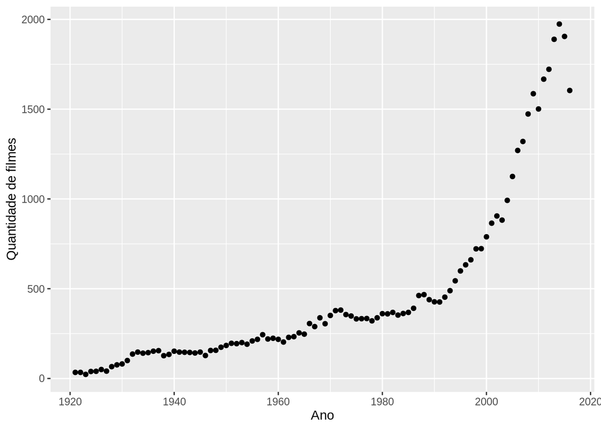

Quantidade de filmes por ano

```r
count_per_year <- movies_root %>%
  group_by(release_year) %>%
  filter(release_year>1920, release_year<2017) %>%
  summarise(count=n()) %>%
  filter(count>20)

ggplot(data = count_per_year, aes(release_year, count)) +
  geom_point() + ylab("Quantidade de filmes") + xlab("Ano")
```

Com o grande número de produções ao longo dos anos, é comum que se tenha uma menor rigidez e cuidado com alguns filmes. Não é de completa justiça afirmar que a qualidade do cinema caiu ao longo dos anos. Fato é que as produções cinematográficas eram centralizadas em grandes produtoras e os filmes recebiam muito mais atenção pois o investimento realizado era muito menor, havendo uma certa cautela.

Mas o cinema tornou-se cada vez mais popular e sua popularidade acaba o fazendo buscar mais públicos-alvo com produções de nicho. Com isso, a quantidade de filmes aumenta e, por consequência, muitos com nem tanto cuidado quanto outros. O gráfico abaixo mostra como a média de avaliações cai ao longo dos anos. O que não necessariamente representa algo ruim, pois até filmes mal criticados possuem seu público-alvo.

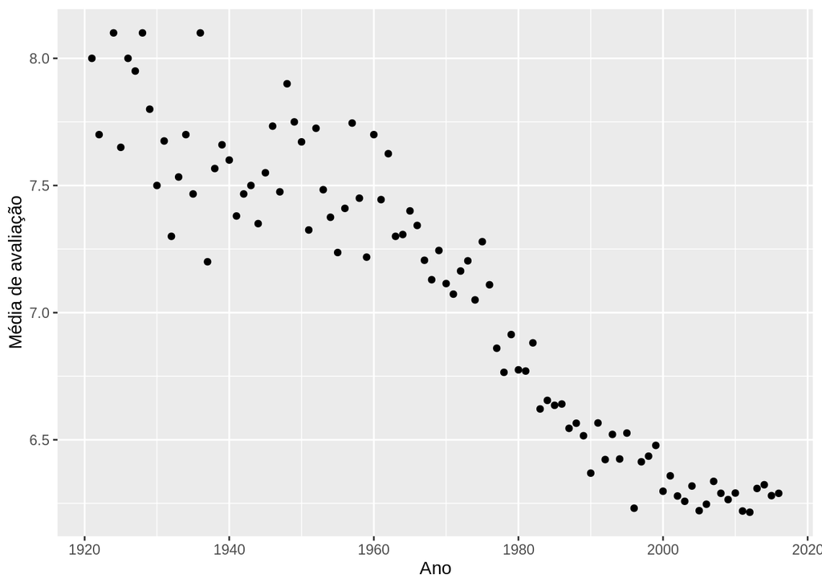

Média de avaliação por ano

```r
average_vote_per_year <- movies_root %>%
  filter(vote_count > 100, release_year>1920, release_year<2017) %>%
  group_by(release_year) %>%
  summarise(average=mean(vote_average))

ggplot(data = average_vote_per_year, aes(average_vote_per_year$release_year, average_vote_per_year$average)) +
  geom_point() + ylab("Média de avaliação") + xlab("Ano")
```

#### **O mercado de gêneros**

Como diferentes ferramentas de abordagem, os filmes agruparam-se em gêneros que se tornaram cada vez mais diversos com o início da “era do som” no começo do século passado. Eram muito comuns os dramas históricos e bíblicos, juntamente com a comédia musical. A diversidade de gêneros que compõe o acervo cinematográfico trazem consigo suas próprias técnicas para transmitir sua mensagem. Algumas mais populares que outras, claro.

Analisando os gêneros, podemos extrair quais deles são melhores avaliados, como no gráfico abaixo. Onde podemos ver que documentários costumam ser filmes bem mais curados e menos produzidos em número, tendo um público alvo bem definido.

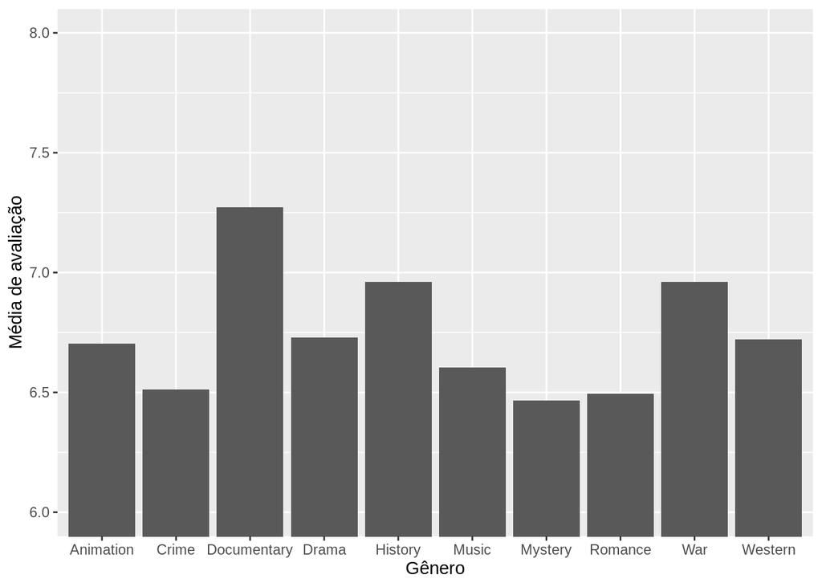

Média de avaliação por gênero

```r
movies_genres <- read.csv("generated_data/movies_genres.csv")

movies_and_genres <- merge(x=movies_root, y=movies_genres, by.x="id", by.y="movie_id")
movies_and_genres <- select(movies_and_genres, id, original_title, genre,
                            vote_average, release_year, title, vote_count)

genre_vote <- movies_and_genres %>%
  filter(vote_count>100) %>%
  select(genre, vote_average) %>%
  group_by(genre) %>%
  summarise(average=mean(vote_average, na.rm = T)) %>%
  arrange(desc(average))

ggplot(genre_vote[1:10,], aes(genre, average)) +
  geom_bar(stat="identity") +
  xlab("Gênero") + ylab("Média de avaliação")+
  coord_cartesian(ylim=c(6,8))
```

Os gêneros mais explorados são um reflexo das primeiras décadas da história do cinema. Filmes de horror, como herança do expressionismo europeu pós-primeira guerra, dividiam salas com as já citadas comédias musicais, dramas bíblicos e filmes de gangsters famosos nos anos 30. A quantidade total de filmes por gênero é mostrada no gŕafico abaixo.

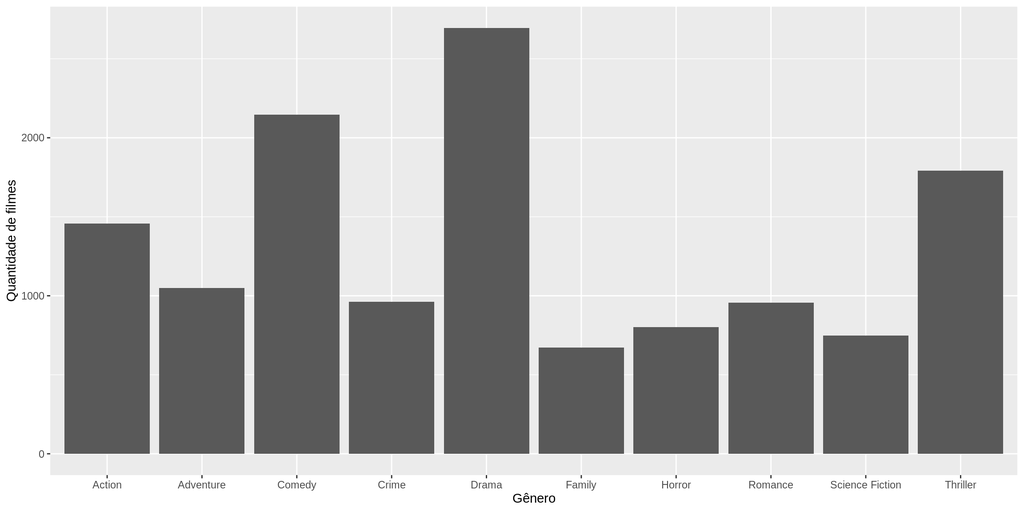

Quantidade de filmes por gênero

```r
genre_count <- movies_and_genres %>%
  filter(vote_count>100) %>%
  group_by(genre) %>%
  summarise(count=n()) %>%
  arrange(desc(count))

ggplot(genre_count[1:10,], aes(genre, count)) +
  geom_bar(stat="identity") +
  xlab("Gênero") + ylab("Quantidade de filmes")
```

Por fim, podemos listar os filmes mais bem avaliados de cada gênero. Em uma seleção bastante diversificada, com filmes lançados em várias décadas distintas. Trazendo desde a febre samurai dos anos 50, com o Chambara japonês, ao musical La La Land de 2016, estrelado pela atriz Emma Stone.

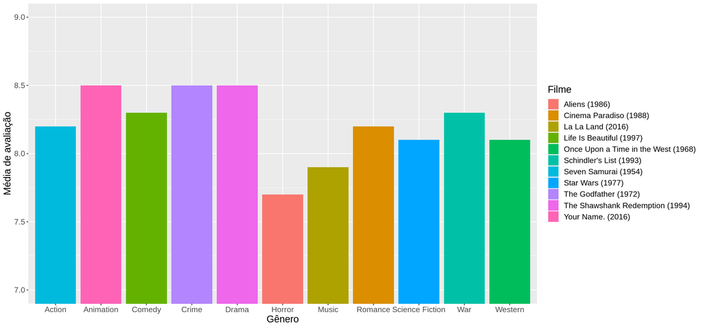

Filmes mais bem avaliados de cada gênero

```r
index <- which(duplicated(movies_and_genres$original_title))
movies_and_genres <- movies_and_genres[-index,]

movies_genre_ratings <- movies_and_genres %>%
  select(title, genre, vote_average, vote_count, release_year) %>%
  group_by(genre) %>%
  filter(vote_count > 800) %>%
  mutate(max_score=max(vote_average)) %>%
  ungroup() %>%
  filter(vote_average==max_score)

movies_genre_ratings <- filter(movies_genre_ratings,
                            genre != "Family", genre != "Adventure",
                            genre != "Mystery", genre != "Fantasy",
                            title != "The Good, the Bad and the Ugly",
                            genre != "History", genre != "Thriller")

names_w_years <- paste(movies_genre_ratings$title, " (",
                       movies_genre_ratings$release_year, ")", sep="")

ggplot(movies_genre_ratings,
       aes(x=as.character(genre),
           y=as.numeric(vote_average),
           fill=names_w_years)) +
  geom_bar(stat="identity", position = "dodge") +
  xlab("Gênero") + ylab("Média de avaliação") + labs(fill="Filme") +
  coord_cartesian(ylim=c(7,9))+
  theme(text = element_text(size=15))
```

#### **Premiações e popularidade**

Não há como falar sobre cinema sem citar as anuais temporadas de premiações, que correspondem ao último trimestre do ano, se estendendo até o mês de janeiro. Nesse período, ocorrem o Globo de Ouro, SAG, Grammy e, principalmente, o Oscar.

A Temporada faz com que filmes de maior potencial sejam lançados próximos do último trimestre, geralmente nos meses de setembro e outubro. Isso é mostrado no gráfico abaixo, o mês de setembro possui uma maior quantidade de filmes com avaliações acima de 6, seguido de perto por dezembro. Os filmes lançados em dezembro geralmente são os últimos a entrarem nas listas das premiações, tendo sido exibido em festivais de cinema internacionais anteriormente, como, por exemplo, Marriage Story — comédia dramática da Netflix — e 1917 — filme de guerra do diretor Sam Mendes —, que tiveram forte presença na Temporada 2019-2020.

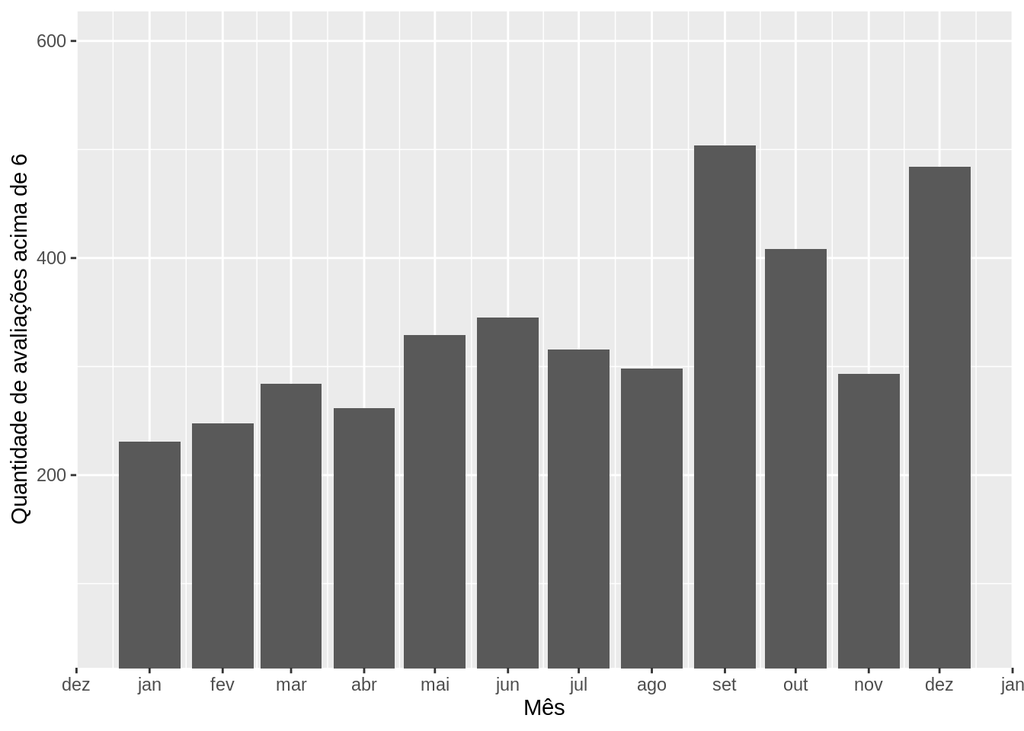

```r
best_movies_per_month <- movies_root %>%
  filter(vote_average>6, vote_count>100) %>%
  select(title, vote_average, release_month) %>%
  group_by(release_month) %>%
  summarise(count=n())

best_movies_per_month <- best_movies_per_month[-13,]
best_movies_per_month$release_month <- as.Date(
  paste0("2020-", best_movies_per_month$release_month, "-1"))

ggplot(best_movies_per_month) +
  geom_bar(mapping = aes(x = release_month, y = count), stat="identity") +
  scale_x_date(labels=date_format("%b"), breaks="1 month") +
  xlab("Mês") +
  ylab("Quantidade de avaliações acima de 6") +
  coord_cartesian(ylim=c(50,600))
```

Embora sejam meses com maior número de lançamentos bem avaliados, estes meses não correspondem aos de maior bilheteria. Estes, por sua vez, costumam corresponder às férias de verão americanas, período que começa do final de maio e perdura até o início de agosto. O salto de arrecadação também acontece durante as férias de inverno, englobando o período de festas de fim de ano, como mostrado no gráfico.

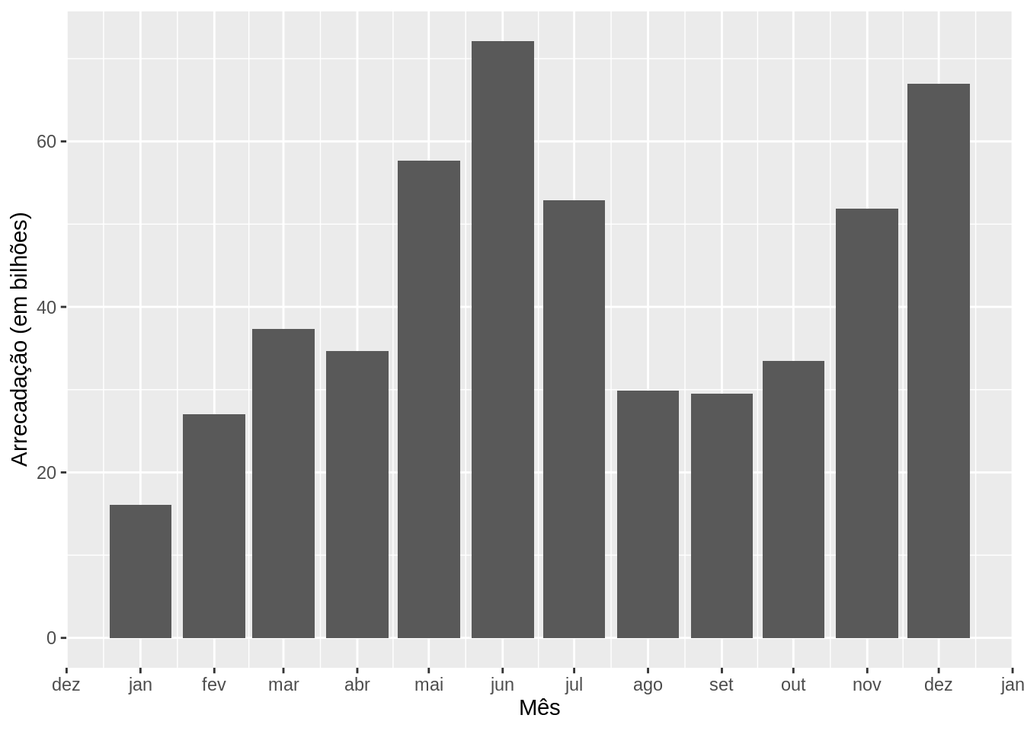

```r
best_revenue_per_month <- movies_root %>%
  filter(vote_average>0) %>%
  select(title, revenue, release_month) %>%
  group_by(release_month) %>%
  summarise(revenue=sum(revenue))

best_revenue_per_month <- best_revenue_per_month[-13,]
best_revenue_per_month$release_month <- as.Date(
  paste0("2020-", best_revenue_per_month$release_month, "-1"))

best_revenue_per_month$revenue <- best_revenue_per_month$revenue/1000000000

ggplot(best_revenue_per_month) +
  geom_bar(mapping = aes(x = release_month, y = revenue), stat="identity") +
  scale_x_date(labels=date_format("%b"), breaks="1 month") +
  xlab("Mês") +
  ylab("Arrecadação (em bilhões)")
```

Esta divergência pode levantar a dúvida se os filmes mais bem avaliados são para público de nicho. Nos últimos anos, o Oscar tem sido alvo de críticas por esnobar filmes populares, de grande arrecadação. Diante da febre dos filmes de ação de bilheterias bilionárias dos últimos anos, a Academia tende sempre a ignorar ou a colocá-los para concorrer em modestas categorias técnicas.

Neste ponto, houveram muitas críticas à falta de democracia com os filmes mais acessíveis. Em 2018, até anunciaram uma nova categoria para “filmes populares”, mas voltaram atrás logo depois. Este fato incomoda, muito pelo fato da premiação estar perdendo cada vez mais audiência televisiva, tendo apresentado a pior da história no ano de 2020.

Neste contexto, surgiu o questionamento: será que filmes com alta avaliação geralmente arrecadam menos? O gráfico abaixo diz que sim. Tirando a média das arrecadações de acordo com a avaliação, os filmes com média acima de 8 costumam ter menos bilheteria que filmes onde a avaliação pertence ao intervalo entre 6 e 7.5.

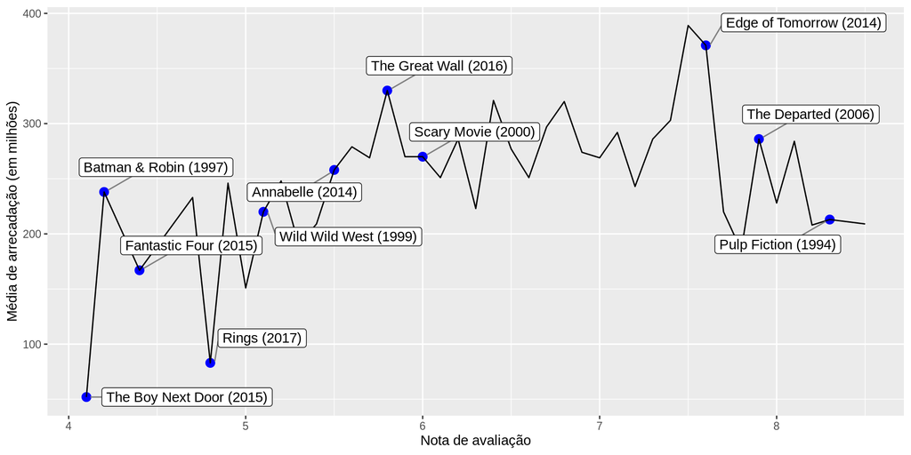

```r
library(ggrepel)
movies_rate_revenue <- movies_root %>%
  select(title, release_year, vote_average, vote_count, revenue)

rate_revenue <- movies_rate_revenue %>%
  filter(vote_count>1000) %>%
  group_by(vote_average) %>%
  summarise(revenue=mean(revenue), title=first(title))

rate_revenue$revenue <- as.integer(rate_revenue$revenue/1000000)

aux_movies <- movies_root %>% select(title, vote_average, revenue, vote_count, release_year) %>%
  filter(vote_count>1000)
aux_movies$revenue <- as.integer(aux_movies$revenue/1000000)

aux_movies$revenue_2 <- as.integer(aux_movies$revenue/10) * 10
rate_revenue$revenue_2 <- as.integer(rate_revenue$revenue/10) * 10

aux_movies <- merge(x=rate_revenue, y=aux_movies, by=c("vote_average", "revenue_2"))
index = which(duplicated(aux_movies$vote_average))
aux_movies <- aux_movies[-index,]

names_w_years <- paste(aux_movies$title.y, " (", aux_movies$release_year, ")", sep="")

ggplot(data=aux_movies, mapping = aes(x=vote_average, y=revenue.x)) +
  geom_point(color="blue", size=3) +
  geom_line(data=rate_revenue, mapping=aes(x=vote_average, y=revenue)) +
  #geom_text(aes(label=title.y), colour="blue") +
  geom_label_repel(aes(label=names_w_years),
                   box.padding=0.35,
                   point.padding=0.5,
                   segment.color="grey50") +
  xlab("Nota de avaliação") +
  ylab("Média de arrecadação (em milhões)")
```

Mas também não podemos afirmar que quanto menor avaliação, maior arrecadação. A linha do gráfico tem uma tendência à queda com notas abaixo de 6. Representando, assim, que não há nada mais democrático que um filme mediano.

### A Era de Ouro

#### **Introdução**

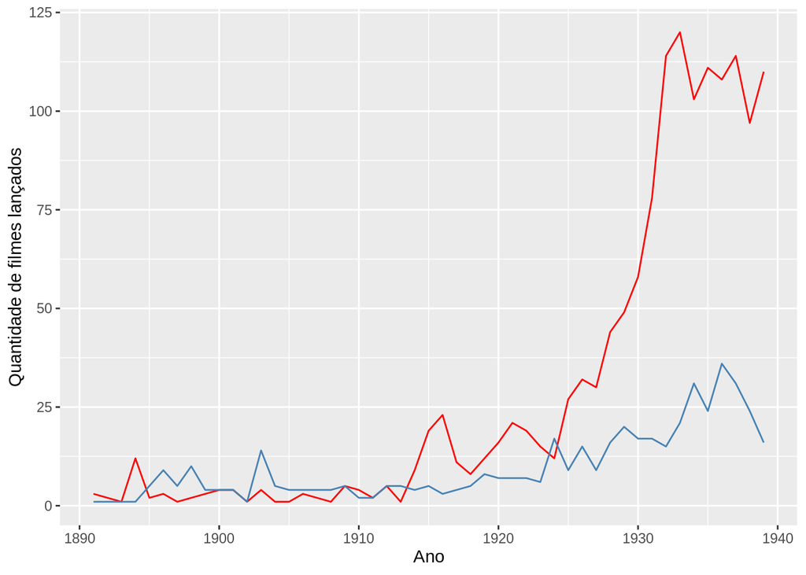

```r
grow_count <- movies_root %>%
    select(release_year, revenue, production_countries) %>%
    filter(release_year<1940, release_year > 1890, production_countries!="[]") %>%
    group_by(release_year,production_countries) %>%
    summarise(count=n(), revenue=sum(revenue))

grow_holly <- grow_count %>%
    filter(production_countries=="United States of America") %>%
    select(release_year, count, production_countries)
grow_rest <- grow_count %>%
    filter(production_countries!="United States of America") %>%
    group_by(release_year) %>%
    summarise(count=sum(count), production_countries="Rest of the World")

ggplot(data=grow_holly, mapping=aes(x=release_year,y=count)) +
    geom_line(color='red') +
    geom_line(data=grow_rest, mapping=aes(x=release_year, y=count), color='steelblue') +
    xlab("Ano") + ylab("Quantidade de filmes lançados") +
    scale_fill_manual(values=c("red", "steelblue"),
                      breaks=c("United States of America", "Rest of the World"),
                      labels=c("United States", "Rest of the World"))
```

Iniciava-se alí a Era de Ouro do Cinema, época de maior desenvolvimento de técnicas cinematógraficas e grandes investimentos em produções, que acabavam atraindo milhões de pessoas para as salas. Foi exatamente nesta época, contrastando com a Grande Guerra, que foram fundados os maiores estúdios da época: Warner Bros. (1923), MGM (1924), RKO (1928), Paramount Pictures (1912) e a Fox Film (1913), chamados *Big Five*. Outros grandes estúdios, *Little Three*, foram fundados nesta época, sendo a Columbia de 1914, a Universal em 1914 e a United Artists, 1919. Estes grandes estúdios até hoje figuram no top 10 dos que mais lançaram filmes até então, com a Warner Bros liderando o ranking.

```r
production_companies <- read.csv("generated_data/production_metadata.csv", stringsAsFactors = F)
movies_productions <- read.csv("generated_data/movies_productions.csv", stringsAsFactors = F)

movies_productions <- merge(movies_productions, production_companies, by.x="production_id", by.y="id")
movies_productions <- merge(movies_root, movies_productions, by.x="id",by.y="movie_id")

count_production <- movies_productions %>%
    group_by(name) %>%
    summarise(count=n()) %>%
    arrange(desc(count))

DT::datatable(count_production[1:10,])
```

|  | name | count |
| --- | --- | --- |
| 1 | Warner Bros. | 1250 |
| 2 | Metro-Goldwyn-Mayer (MGM) | 1080 |
| 3 | Paramount Pictures | 1007 |
| 4 | Twentieth Century Fox Film Corporation | 836 |
| 5 | Universal Pictures | 830 |
| 6 | Columbia Pictures Corporation | 448 |
| 7 | Canal+ | 442 |
| 8 | Columbia Pictures | 431 |
| 9 | RKO Radio Pictures | 290 |
| 10 | United Artists | 279 |

#### **Anos 20**

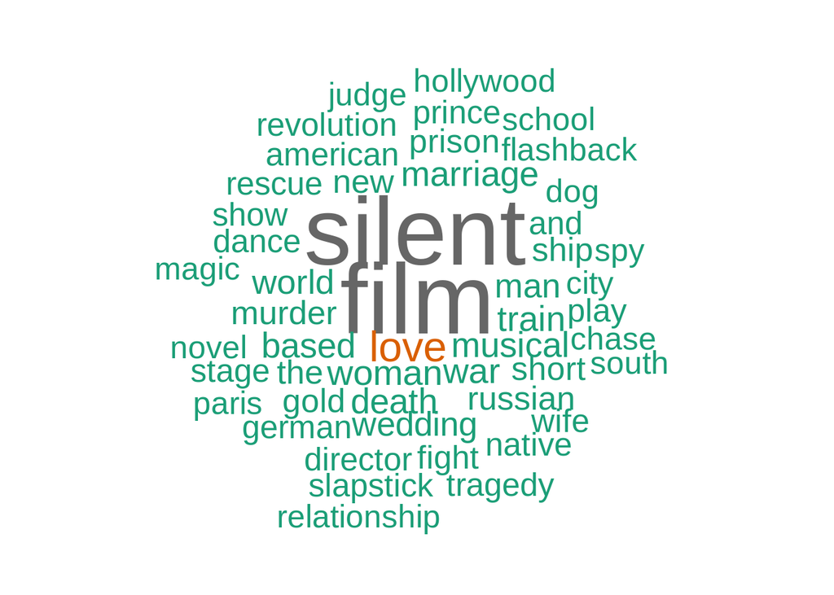

Nuvem de palavras mais frequentes em filmes de década de 20

```r
keywords <- read.csv("generated_data/keywords.csv", stringsAsFactors = F)

movies_word <- merge(x=movies_root, y=keywords, by.x="id", by.y="movie_id")
movies_word <- select(movies_word, id, belongs_to_collection, title,
                      release_year, release_month, revenue, vote_count,
                      vote_average, keyword)

decade_keyword <- movies_word %>%
  select(release_year, keyword)
decade_keyword$decade <- as.integer(decade_keyword$release_year/10)*10

# década 20
word20 <- paste(
  filter(decade_keyword, decade==1920)$keyword,
  collapse = " "
)

word20 <- Corpus(VectorSource(word20))
matrix <- as.matrix(TermDocumentMatrix(word20))
word20 <- sort(rowSums(matrix),decreasing=TRUE)
word20 <- data.frame(word = names(word20),freq=word20)

wordcloud(words = word20$word, freq = word20$freq,
          min.freq=1, max.words=50,
          random.order=F, rot.per=0,
          colors=brewer.pal(8, "Dark2"),
          scale=c(5,1.5))
```

Com a chegada dos anos 20, o mercado audiovisual começa a crescer cada vez mais nos Estados Unidos, com o cinema mudo e suas comédias pastelões popularizadas pelo ator britânico Charles Chaplin. Entre as palavras mais citadas em filmes da época, encontra-se “silent” que descreve o estilo das produções, e bastantes referências à Guerra, como as palavras “war”, “german” e “russian” presentes na nuvem de palavras acima.

#### **Anos 30**

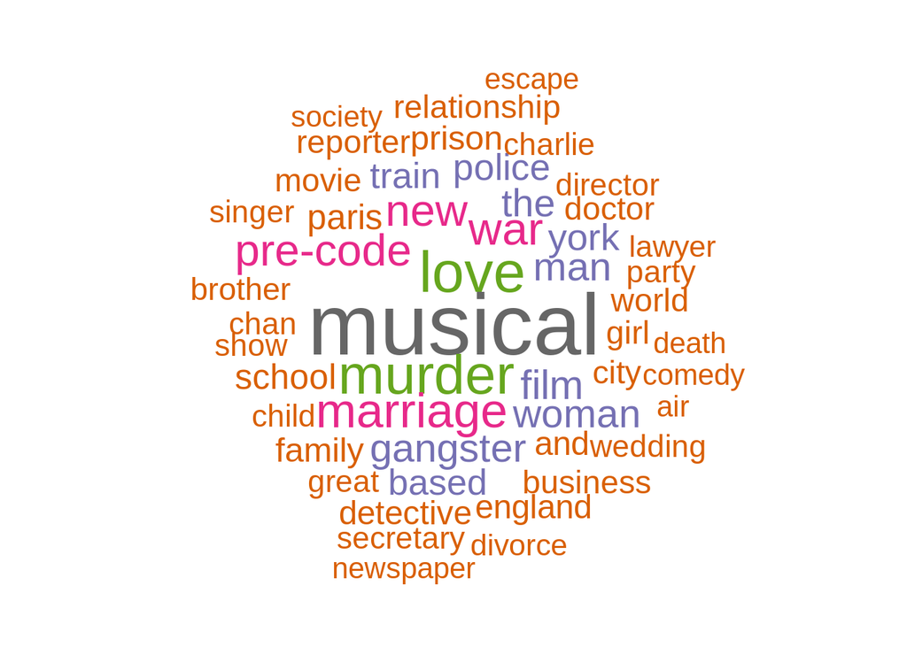

Nuvem de palavras mais frequentes em filmes de década de 30

```r
word30 <- paste(
  filter(decade_keyword, decade==1930)$keyword,
  collapse = " "
)

word30 <- Corpus(VectorSource(word30))
matrix <- as.matrix(TermDocumentMatrix(word30))
word30 <- sort(rowSums(matrix),decreasing=TRUE)
word30 <- data.frame(word = names(word30),freq=word30)

wordcloud(words = word30$word, freq = word30$freq,
          min.freq=1, max.words=50,
          random.order=F, rot.per=0,
          colors=brewer.pal(8, "Dark2"),
          scale=c(4,.9))
```

O cinema passa a ter uma importância ainda maior na década subsequente, pois, com a Crise de 1929, o entretenimento audiovisual era usado como uma fuga da realidade de um ambiente imerso em desolador desespero.

Com a chegada do som, os musicais ganham as telonas e aparecem como palavra-chave mais recorrente na nossa nuvem de palavras da década. Comédias românticas também dão um tom mais leve às produções da época, que também contam com uma ascenção dos filmes de faroeste. É ainda nesta década que grandes filmes da história do cinema são lançados: Mágico de Oz e E o Vento Levou, ambos de 1939.

#### **Anos 40**

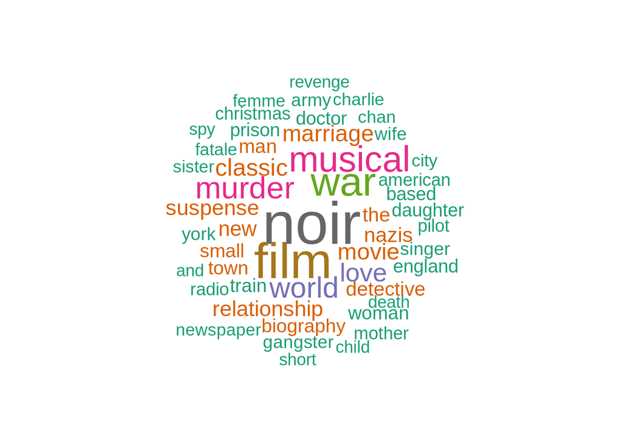

Nuvem de palavras mais frequentes em filmes de década de 40

```r
word40 <- paste(
  filter(decade_keyword, decade==1940)$keyword,
  collapse = " "
)

word40 <- Corpus(VectorSource(word40))
matrix <- as.matrix(TermDocumentMatrix(word40))
word40 <- sort(rowSums(matrix),decreasing=TRUE)
word40 <- data.frame(word = names(word40),freq=word40)

wordcloud(words = word40$word, freq = word40$freq,
          min.freq=1, max.words=50,
          random.order=F, rot.per=0,
          colors=brewer.pal(8, "Dark2"),
          scale=c(4,0.9))
```

Os anos 40 chegam e trazem consigo a Segunda Guerra Mundial, que é refletida nas telonas com grandes produções como Cidadão Kane (1941). Outra grande febre dos anos 40 são os filmes *noir*, estética alemã que ganha popularidade nos EUA nesta época, conhecido por filmes de alto-contraste, combinando ambientação urbana e suspense criminal.Por esses motivos, a nuvem de palavras dessa década está repleta de termos relacionadas à violência.

#### **Anos 50 e 60**

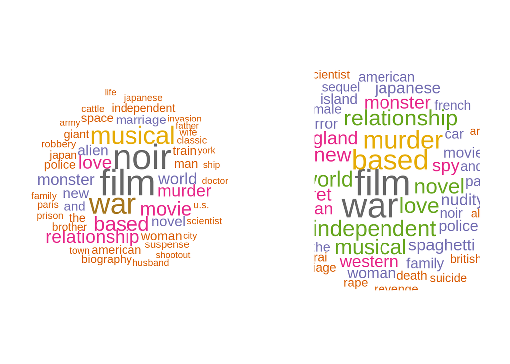

Nuvem de palavras mais frequentes em filmes de década de 50 e 60

```r
layout(matrix(c(1, 2), nr=1, byrow=T))
# década 50
word50 <- paste(
  filter(decade_keyword, decade==1950)$keyword,
  collapse = " "
)

word50 <- Corpus(VectorSource(word50))
matrix <- as.matrix(TermDocumentMatrix(word50))
word50 <- sort(rowSums(matrix),decreasing=TRUE)
word50 <- data.frame(word = names(word50),freq=word50)

wordcloud(words = word50$word, freq = word50$freq,
          min.freq=1, max.words=50,
          random.order=F, rot.per=0,
          colors=brewer.pal(8, "Dark2"),
          scale=c(3,0.4))

# década 60
word60 <- paste(
  filter(decade_keyword, decade==1960)$keyword,
  collapse = " "
)

word60 <- Corpus(VectorSource(word60))
matrix <- as.matrix(TermDocumentMatrix(word60))
word60 <- sort(rowSums(matrix),decreasing=TRUE)
word60 <- data.frame(word = names(word60),freq=word60)

wordcloud(words = word60$word, freq = word60$freq,
          min.freq=1, max.words=50,
          random.order=F, rot.per=0,
          colors=brewer.pal(8, "Dark2"),
          scale=c(3,0.4))
```

No declínio da Era de Ouro de Hollywood, o mundo do cinema já não estava mais tão preso em território norte-americano. O resto do mundo começava a se recuperar das guerras e dava seus pequenos passos em direção à retomada. Nesta época, se popularizou o cinema japonês, focado em ação com samurais.

Nesta época, a televisão começou a se popularizar, reduzindo o lucros e levando produtoras a encerrar contratos. Por conta disso, começou a se popularizar os filmes “B”, de menor orçamento e utilizando de narrativas com sexo e romances novelescos.

É comum ver nas nuvens de palavras, termos que remetem à ficção científica, como “space”, “alien”, “scientist” e “monster”. Este gênero foi impulsionado pela corrida espacial durante a Guerra Fria no começo dos anos 50, com tramas geralmente relacionadas ao “perigo comunista”.

### Mercado de franquias

#### Mercado

A derrocada da Era de Ouro de Hollywood coincide com uma ascenção de franquias de filmes com o intuito de reaproveitar sucessos de bilheteria para levar cada vez mais pessoas ao cinema. O fenômeno aumentou nos anos 70, quando *The Godfather: Part II* se torna a primeira sequência a ganhar o prêmio de melhor filme no Oscar.

O mercado das franquias cresce cada vez mais a cada ano, sendo, na maioria das vezes, as maiores bilheterias do ano. Se observarmos as 10 maiores arrecadações do ano de 2019, 7 filmes são sequências diretas de outros filmes. Abrangendo esta análise para os últimos 100 anos da história do cinema, filtramos as 50 maiores arrecadações a cada ano e contamos quantas delas são franquias, o resultado está no gráfico abaixo.

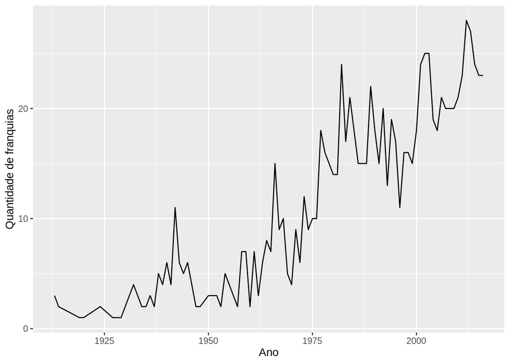

Quantidade de franquias nas 50 maiores arrecadações por ano

```r
franchise_revenue <- movies_root[order(movies_root$revenue, decreasing=T), ]
franchise_revenue <- by(franchise_revenue, franchise_revenue["release_year"], head, n=50)
franchise_revenue <- Reduce(rbind, franchise_revenue)

franchise_revenue <- franchise_revenue %>%
    filter(!is.na(belongs_to_collection), release_year<2017) %>%
    group_by(release_year) %>%
    summarise(count=n())

ggplot(data=franchise_revenue, aes(x=release_year,y=count)) +
  geom_line() + xlab("Ano") + ylab("Quantidade de franquias")
```

Podemos ver que os anos 2000 representam uma nova ascenção nas franquias que haviam estado em leve queda no fim dos anos 90. Impulsionado por *Harry Potter* e *Lord of The Rings*, o mercado das coleções cinematográficas volta a crescer no novo século, tendo outra queda na metade da primeira década, porém, se recuperando com a nova onda de filmes de herói e sagas infanto-juvenis, como Twilight e The Hunger Games.

#### Maiores arrecadações

No gráfico abaixo com as mais lucrativas franquias de todos os tempos, tem-se grande parte delas recentes. E mesmo as que não são deste século, permanecem sendo lançadas até hoje (o ano descrito no gráfico se refere ao ano de lançamento do primeiro filme).

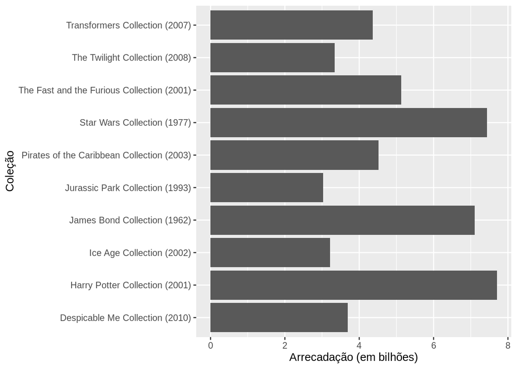

Franquias mais lucrativas

```r
cond = is.na(movies_root$belongs_to_collection)
only_collections = movies_root[!cond,]

collections_revenue <- only_collections %>%
  select(belongs_to_collection, revenue, release_year) %>%
  group_by(belongs_to_collection) %>%
  summarise(total_revenue=sum(revenue), year=min(release_year)) %>%
  arrange(desc(total_revenue))

collections_revenue$belongs_to_collection <- paste(collections_revenue$belongs_to_collection,
                                                  " (", collections_revenue$year, ")", sep="")
collections_revenue$total_revenue <- collections_revenue$total_revenue/1000000000

ggplot(collections_revenue[1:10,], aes(total_revenue, belongs_to_collection)) +
  geom_bar(stat="identity") +
  ylab("Coleção") + xlab("Arrecadação (em bilhões)")
```

Comparar arrecadação de franquias de diferentes épocas pode não corresponder com fidelidade a realidade do mercado pois os valores não estão reajustados com a inflação. Portanto, podemos ver abaixo as coleções de filmes que mais arrecadaram por década, podendo observar que o início da fama deste formato coincide com o fim da Era de Ouro, com as produtoras arriscando novas estratégias para manter o público nas salas de cinema. Também é importante ressaltar que a arrecadação da década de 2010 corresponde aos filmes lançados até o ano de 2016.

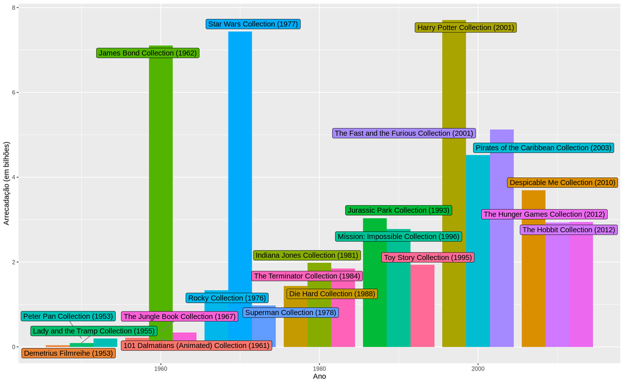

Franquias mais lucrativas por década

```r
cond = is.na(movies_root$belongs_to_collection)
only_collections = movies_root[!cond,]

collections_revenue <- only_collections %>%
  select(belongs_to_collection, revenue, release_year) %>%
  group_by(belongs_to_collection) %>%
  summarise(total_revenue=sum(revenue), year=min(release_year)) %>%
  arrange(desc(total_revenue)) %>%
  filter(year>1950)
collections_revenue$belongs_to_collection <- paste(collections_revenue$belongs_to_collection,
                                                   " (", collections_revenue$year, ")", sep="")
collections_revenue$total_revenue <- collections_revenue$total_revenue/1000000000
collections_revenue$decade <- as.integer(collections_revenue$year/10) * 10

collections_revenue_decade <- collections_revenue[order(collections_revenue$total_revenue, decreasing=T), ]
collections_revenue_decade <- by(collections_revenue_decade, collections_revenue_decade["decade"], head, n=3)
collections_revenue_decade <- Reduce(rbind, collections_revenue_decade)

ggplot(collections_revenue_decade, aes(x=decade,y=total_revenue,fill=belongs_to_collection)) +
  geom_bar(stat="identity", position = "dodge") + guides(fill=FALSE) +
  xlab("Ano") + ylab("Arrecadação (em bilhões)") + labs(fill="") +
  geom_label_repel(aes(label=belongs_to_collection),
                   segment.color="grey50")
```

#### Mais bem avaliados

A força das franquias cinematográficas do século 21 também pode ser observada listando as 10 mais bem avaliadas franquias da história do cinema. No topo, a estimada trilogia *The Lord of the Rings*, lançada em 2001, baseada na obra de J. R. R. Tolkien, é a mais bem-sucedida franquia cinematográfica de todos os tempos. Além de faturar pouco mais de 2.9 bilhões de dólares no mundo todo, a trilogia é recorde de indicações e conquistas do Oscar no formato, sendo indicada 30 vezes e vencendo 17 delas. Apenas *Return of the King*, terceiro filme da franquia recebeu 11 indicações, se igualando a *Titanic* e *Ben-Hur* como recordistas no segmento.

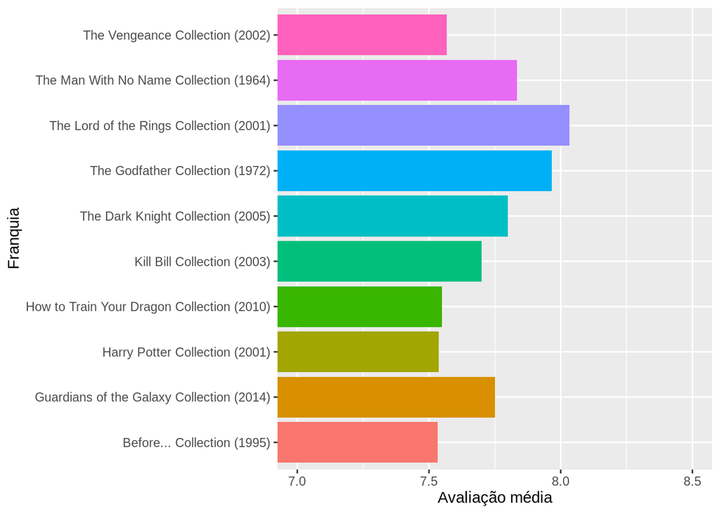

Franquias mais bem avaliadas

```r
cond = is.na(movies_root$belongs_to_collection)
only_collections = movies_root[!cond,]

collections_rating <- only_collections %>%
  select(belongs_to_collection, release_year, vote_average, vote_count) %>%
  group_by(belongs_to_collection) %>%
  summarise(average_rating=mean(vote_average),
            year=min(release_year),
            average_count=mean(vote_count),
            count=n()) %>%
  arrange(desc(average_rating)) %>%
  filter(count>1, average_count>500, year>1959)

collections_rating$belongs_to_collection <- paste(collections_rating$belongs_to_collection,
                                                   " (", collections_rating$year, ")", sep="")

ggplot(collections_rating[1:10,], aes(average_rating, belongs_to_collection, fill=belongs_to_collection)) +
  geom_bar(stat="identity") + scale_fill_discrete(guide=FALSE) +
  xlab("Avaliação média") + ylab("Franquia") +
  coord_cartesian(xlim=c(7,8.5))
```

A importância dos filmes de héroi no mercado de franquias é notável. O século 21 apresenta, em suas duas primeiras décadas, franquias como *The Dark Night* e *Guardians of the Galaxy*, em seus top 3 de mais bem avaliados. O trilogia do homem-morcego dirigida por Christopher Nolan foi o primeiro grande investimento da DC Comics no mercado audiovisual neste século, conseguindo conquistar um Oscar de “Melhor Ator Coadjuvante” para Heath Ledger, que viveu o Coringa no segundo filme.

No gráfico abaixo, é importante salientar que, assim como nas arrecadações, a coleção é agrupada de acordo com o ano do seu primeiro filme.

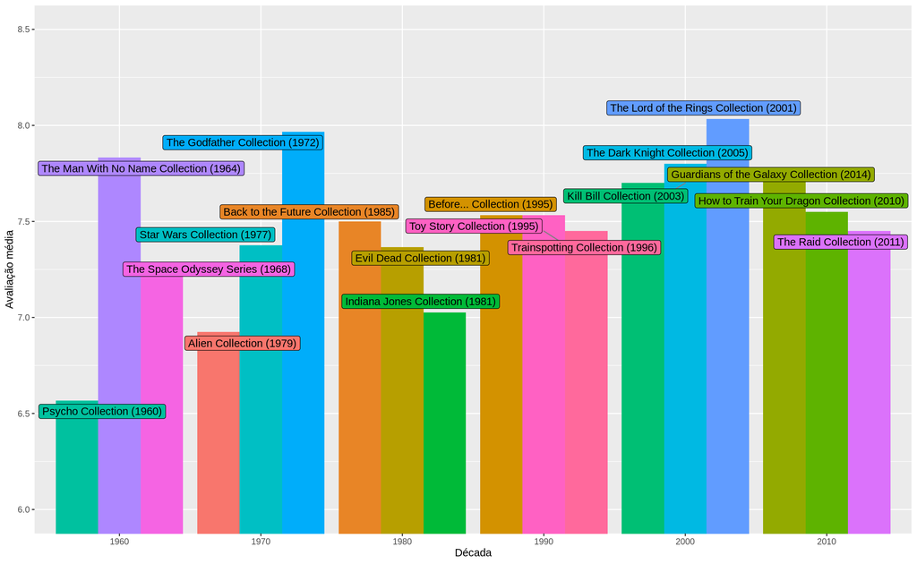

Franquias mais bem avaliadas por década

```r
cond = is.na(movies_root$belongs_to_collection)
only_collections = movies_root[!cond,]

collections_rating <- only_collections %>%
  select(belongs_to_collection, release_year, vote_average, vote_count) %>%
  group_by(belongs_to_collection) %>%
  summarise(average_rating=mean(vote_average),
            year=min(release_year),
            average_count=mean(vote_count),
            count=n()) %>%
  arrange(desc(average_rating)) %>%
  filter(count>1, average_count>500, year>1959)

collections_rating$belongs_to_collection <- paste(collections_rating$belongs_to_collection,
                                                  " (", collections_rating$year, ")", sep="")
collections_rating$decade <- as.integer(collections_rating$year/10) * 10

better_rating_decade <- collections_rating[order(collections_rating$average_rating, decreasing=T), ]
better_rating_decade <- by(better_rating_decade, better_rating_decade["decade"], head, n=3)
better_rating_decade <- Reduce(rbind, better_rating_decade)

ggplot(better_rating_decade,
       aes(x=as.character(decade),
           y=as.numeric(average_rating),
           fill=belongs_to_collection)) +
  geom_bar(stat="identity", position = "dodge") +
  xlab("Década") + ylab("Avaliação média") + labs(fill="Collection") +
  coord_cartesian(ylim=c(6,8.5)) +
  geom_label_repel(aes(label=belongs_to_collection),
                   segment.color="grey50") +
  scale_fill_discrete(guide=FALSE)
```

### O Cinema fora de Hollywood

#### Introdução

O recente acontecimento inédito na história do Oscar não chegou a ser uma surpresa para quem acompanha o cinema de fora do solo estadunidense. A vitória de *Parasite* (2019) na categoria “Melhor Filme” da premiação é, para muitos, um troféu de justiça pelos tantos anos que filmes fantásticos foram esnobados pela Academia.

O crescimento do cinema estrangeiro é aparente principalmente no final do século passado. Embora tenha tido uma crescente no pós-guerra, como vemos no gráfico abaixo, quando os países se recuperavam dos estragos, foi nos anos 90 que a curva realmente ascendeu. Produções memoráveis como *The Life is Beatiful* (1997) e *Central do Brasil* (1998) são lançadas, fazendo grande disputa no Oscar de 1999 em “Melhor Filme Estrangeiro”, por muitos considerados a edição que o Brasil mais chegou perto de ganhar uma estatueta.

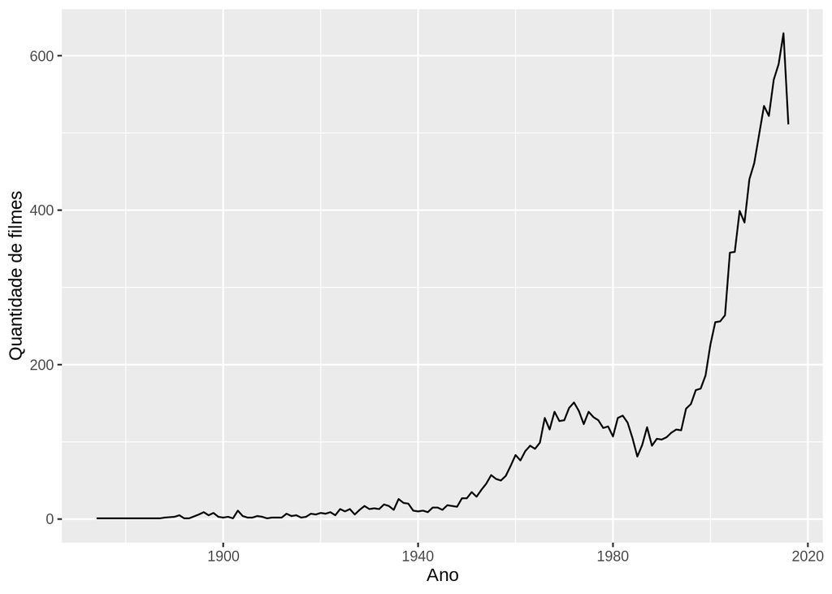

Quantidade de filmes estrangeiros por ano

```r
international_movies <- movies_root %>%
  filter(original_language != "en")

international_count_year <- international_movies %>%
    filter(release_year<2017) %>%
    group_by(release_year) %>%
    summarise(count=n())

ggplot(international_count_year, aes(release_year, count)) +
    geom_line() + xlab("Ano") + ylab("Quantidade de filmes")
```

#### Maiores arrecadações

A França alcança seu pico em 2011, com a estreia de *The Intouchables*, comédia dramática que se tornou o filme mais rentável da história do cinema francês e arrecadou cerca de 420 milhões de dólares. Já o pico do cinema chinês em 2015 se deve muito à animação *Monster Hunt* e à fantasia *Mojin: The Lost Legend*, ambos sucessos de bilheteria deixaram o mercado audiovisual chinês em alta naquele ano.

[figure not shown]

Línguas estrangeiras com maiores arrecadações nos últimos anos

```r
international_movies[international_movies$original_language == "ta",]$original_language <- "hi"
international_movies[international_movies$original_language == "cn",]$original_language <- "zh"

international_revenue <- international_movies %>%
  filter(release_year>2006, release_year<2017) %>%
  group_by(original_language, release_year) %>%
  summarise(revenue=sum(revenue)) %>%
  arrange(desc(revenue))

international_revenue_year <- international_revenue[order(international_revenue$revenue, decreasing=T), ]
international_revenue_year <- by(international_revenue_year, international_revenue_year["release_year"], head, n=3)
international_revenue_year <- Reduce(rbind, international_revenue_year)

international_revenue_year$revenue <- international_revenue_year$revenue/1000000

ggplot(international_revenue_year,
       aes(x=release_year,
           y=revenue,
           fill=original_language)) +
  geom_bar(stat="identity", position = "dodge") +
  xlab("Ano") + ylab("Arrecadação (em milhões)") +
  geom_label_repel(aes(label=original_language),
                   segment.color="grey50") +
  scale_fill_discrete(name = "Línguas", labels = c("zh: Chinês", "de: Alemão",
                                                   "fr: Francês", "hi: Hindi",
                                                   "ja: Japonês", "ko: Coreano",
                                                   "ru: Russo", "sv: Sueco",
                                                   "tr: Turco"))
```

```r
international_revenues <- international_movies %>%
  select(title, release_year, revenue) %>%
  arrange(desc(revenue))

DT::datatable(international_revenues)
```

|  | title | release_year | revenue |
| --- | --- | --- | --- |
| 1 | The Intouchables | 2011 | 426480871 |
| 2 | Monster Hunt | 2015 | 385284817 |
| 3 | Your Name. | 2016 | 355298270 |
| 4 | Dangal | 2016 | 310000000 |
| 5 | Mojin: The Lost Legend | 2015 | 278300000 |
| 6 | Spirited Away | 2001 | 274925095 |
| 7 | Kung Fu Yoga | 2017 | 254212245 |
| 8 | Howl's Moving Castle | 2004 | 234710455 |
| 9 | Baahubali 2: The Conclusion | 2017 | 230000000 |
| 10 | Life Is Beautiful | 1997 | 229400000 |

[output cut: 13184 more lines]

Filmes estrangeiros com maiores arrecadações

#### Mais bem avaliados

O cinema brasileiro da última década tem presença forte no top 3 de filmes estrangeiros mais bem avaliados ano a ano. Os dramas *Hoje Eu Quero Voltar Sozinho* (2014) e *Entre Abelhas* (2015) são os principais responsábeis por colocar o cinema nacional no top 3 dos seus respectivos anos.

Mas a principal língua que vemos no gráfico abaixo é a coreana. O cinema da Coréia do Sul está em alta e não é de hoje, os incentivos públicos no audiovisual local é impressionantemente evidente não apenas no grande triunfo que conseguiu *Parasite* no último ano, mas em todo o século corrente. Os dramas *Mother* (2009) e *I Saw The Devil* (2010) e o terror *Train to Busan* (2016) são grandes exemplos da qualidade do cinema coreano.

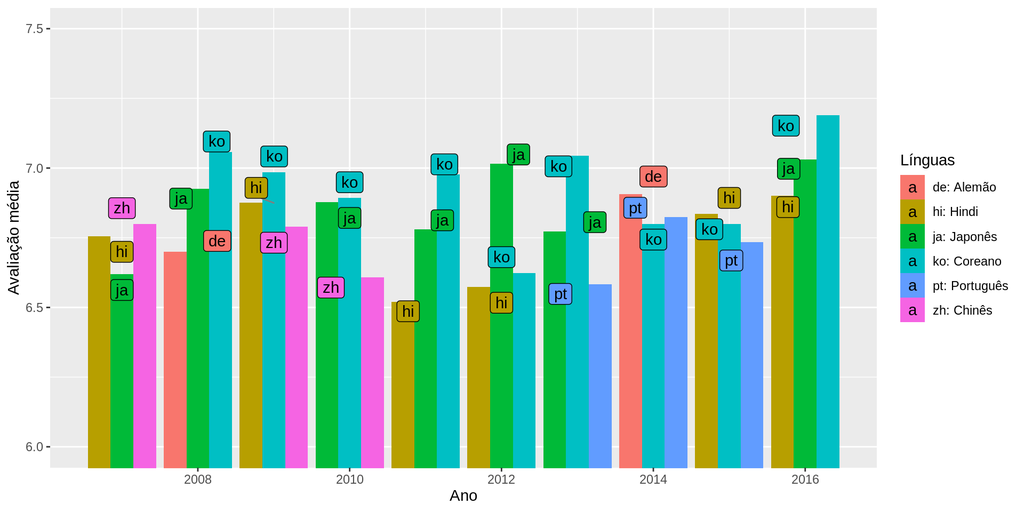

Línguas estrangeiras mais bem avaliadas

```r
international_rating_avg <- international_movies %>%
  filter(release_year>2006, release_year<2017, vote_count>20) %>%
  group_by(original_language, release_year) %>%
  summarise(rating=mean(vote_average), count=n()) %>%
  filter(count>5) %>%
  arrange(desc(rating))


international_rating_year <- international_rating_avg[order(international_rating_avg$rating, decreasing=T), ]
international_rating_year <- by(international_rating_year, international_rating_year["release_year"], head, n=3)
international_rating_year <- Reduce(rbind, international_rating_year)

ggplot(international_rating_year,
       aes(x=release_year,
           y=rating,
           fill=original_language)) +
  geom_bar(stat="identity", position = "dodge") +
  xlab("Ano") + ylab("Avaliação média") +
  geom_label_repel(aes(label=original_language),
                   segment.color="grey50") +
  coord_cartesian(ylim=c(6,7.5)) +
  scale_fill_discrete(name = "Línguas", labels = c("de: Alemão",  "hi: Hindi",
                                                   "ja: Japonês", "ko: Coreano",
                                                   "pt: Português", "zh: Chinês"))
```

```r
international_rating <- international_movies %>%
  filter(vote_count>20) %>%
  select(title, release_year, vote_average) %>%
  arrange(desc(vote_average))

DT::datatable(international_rating)
```

|  | title | release_year | vote_average |
| --- | --- | --- | --- |
| 1 | Dilwale Dulhania Le Jayenge | 1995 | 9.1 |
| 2 | Sansho the Bailiff | 1954 | 8.7 |
| 3 | Human | 2015 | 8.6 |
| 4 | Cosy Dens | 1999 | 8.6 |
| 5 | The Human Condition I: No Greater Love | 1959 | 8.5 |
| 6 | The Human Condition II: Road to Eternity | 1959 | 8.5 |
| 7 | Iron Maiden: Flight 666 | 2009 | 8.5 |
| 8 | The Man Who Sleeps | 1974 | 8.5 |
| 9 | Your Name. | 2016 | 8.5 |
| 10 | Parched | 2015 | 8.5 |

[output cut: 3578 more lines]

Filmes estrangeiros mais bem avaliados

## Conclusão

Com a análise realizada em cima dos dados do dataset, podemos observar alguns aspectos não tão claros no mercado cinematográfico. O crescimento de Hollywood em relação a outros mercados, a relação de popularidade e avaliação e a tendência temática em cada ano da Era de Ouro foram alguns desses pontos.

Com os dados analisados e as informações descobertas, pôde-se avaliar quais os meses são lançados os filmes mais bem avaliados, os mercados estrangeiros mais populares e a relação da popularidade do filme com sua avaliação. Esses dados podem ser úteis para estúdios escolherem produções estrangeiras mais promissoras para investir e como e quando lançar um filme.

A limitação de tempo impediu que mais análises pudessem ser realizadas, poderíamos tratar dos temas mais abordados em cada país e até ano a ano, utilizando as palavras chaves de cada filme. Realizar o tratamento nas sinopses dos filmes para extrair palavras mais frequentes e tentar entender quais assuntos o mercado mais busca abordar ao longo dos anos. Porém, esse tipo de extração e análise deverá ficar para outra oportunidade.

Por fim, o mercado de cinema é muito vasto, muita coisa pôde ser explorada e muitas ainda poderiam ser. O dataset usado tem suas limitações, como a falta de informações em algumas linhas, mas no geral, é bastante completo, trazendo dados que puderam ser utilizados para extrair gráficos e tabelas de diferentes formatos.